# Task_to_do

## Setting up the Environment

It will be using PyTorch to train a convolutional neural network to recognize MNIST's handwritten digits. PyTorch is a very popular framework for deep learning like Tensorflow, CNTK and Caffe2. But unlike these other frameworks PyTorch has dynamic execution graphs, meaning the computation graph is created on the fly.

```python
import torch
import torchvision
```

## Preparing the Dataset

With the imports in place it can go ahead and prepare the data that will be using. But before, the hyperparameters should be defined that will be using for the experiment. Here the number of epochs defines how many times it will loop over the complete training dataset, while learning_rate and momentum are hyperparameters for the optimizer that it will use later on.

```python
n_epochs = 3
batch_size_train = 64
batch_size_test = 1000
learning_rate = 0.01
momentum = 0.5
log_interval = 10

random_seed = 1
torch.backends.cudnn.enabled = False
torch.manual_seed(random_seed)
```

```
<torch._C.Generator at 0x210889a4090>
```

For repeatable experiments it has to set random seeds for anything using random number generation - this means numpy and random as well! It's also worth mentioning that cuDNN uses nondeterministic algorithms which can be disabled setting torch.backends.cudnn.enabled = False.

Now it will also need DataLoaders for the dataset. This is where TorchVision comes into play. It let's use load the MNIST dataset in a handy way. It will use a batch_size of 64 for training and size 1000 for testing on this dataset. The values 0.1307 and 0.3081 used for the Normalize() transformation below are the global mean and standard deviation of the MNIST dataset, it will take them as a given here.

TorchVision offers a lot of handy transformations, such as cropping or normalization.

```python
train_loader = torch.utils.data.DataLoader(
  torchvision.datasets.MNIST('../files/', train=True, download=True,
                             transform=torchvision.transforms.Compose([
                               torchvision.transforms.ToTensor(),
                               torchvision.transforms.Normalize(
                                 (0.1307,), (0.3081,))
                             ])),
  batch_size=batch_size_train, shuffle=True)

test_loader = torch.utils.data.DataLoader(
  torchvision.datasets.MNIST('../files/', train=False, download=True,
                             transform=torchvision.transforms.Compose([
                               torchvision.transforms.ToTensor(),
                               torchvision.transforms.Normalize(
                                 (0.1307,), (0.3081,))
                             ])),
  batch_size=batch_size_test, shuffle=True)
```

PyTorch's DataLoader contain a few interesting options other than the dataset and batch size. For example it could use num_workers > 1 to use subprocesses to asynchronously load data or using pinned RAM (via pin_memory) to speed up RAM to GPU transfers. But since these mostly matter when it is using a GPU it can omit them here.

Now let's take a look at some examples. It will use the test_loader for this.

```python
examples = enumerate(test_loader)
batch_idx, (example_data, example_targets) = next(examples)
```

Ok let's see what one test data batch consists of.

```python
example_data.shape
```

```
torch.Size([1000, 1, 28, 28])
```

So one test data batch is a tensor of shape: torch.Size([1000, 1, 28, 28]). This means it has 1000 examples of 28x28 pixels in grayscale (i.e. no rgb channels, hence the one). Let's plot some of them using matplotlib.

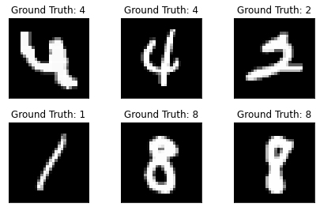

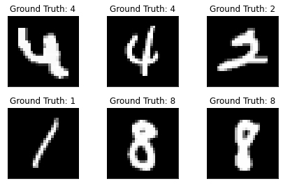

```python
import matplotlib.pyplot as plt

fig = plt.figure()
for i in range(6):
    plt.subplot(2,3,i+1)
    plt.tight_layout()
    plt.imshow(example_data[i][0], cmap='gray', interpolation='none')
    plt.title("Ground Truth: {}".format(example_targets[i]))
    plt.xticks([])
    plt.yticks([])
fig
```

Alright, those shouldn't be too hard to recognize after some training.

## Building the Network

Now let's go ahead and build our network. It will use two 2-D convolutional layers followed by two fully-connected (or linear) layers. As activation function it will choose rectified linear units (ReLUs in short) and as a means of regularization it will use two dropout layers. In PyTorch a nice way to build a network is by creating a new class for the network that it should to build. Let's import a few submodules here for more readable code.

```python
import torch.nn as nn
import torch.nn.functional as F
import torch.optim as optim
```

```python
class Net(nn.Module):
    def __init__(self):
        super(Net, self).__init__()
        self.conv1 = nn.Conv2d(1, 10, kernel_size=5)
        self.conv2 = nn.Conv2d(10, 20, kernel_size=5)
        self.conv2_drop = nn.Dropout2d()
        self.fc1 = nn.Linear(320, 50)
        self.fc2 = nn.Linear(50, 10)

    def forward(self, x):
        x = F.relu(F.max_pool2d(self.conv1(x), 2))
        x = F.relu(F.max_pool2d(self.conv2_drop(self.conv2(x)), 2))
        x = x.view(-1, 320)
        x = F.relu(self.fc1(x))
        x = F.dropout(x, training=self.training)
        x = self.fc2(x)
        return F.log_softmax(x, dim = 1)
```

Broadly speaking think of the torch.nn layers as which contain trainable parameters while torch.nn.functional are purely functional. The forward() pass defines the way it computes output using the given layers and functions. It would be perfectly fine to print out tensors somewhere in the forward pass for easier debugging. This comes in handy when experimenting with more complex models. Note that the forward pass could make use of e.g. a member variable or even the data itself to determine the execution path - and it can also make use of multiple arguments!

Now let's initialize the network and the optimizer.

```python
network = Net()
optimizer = optim.SGD(network.parameters(), lr=learning_rate,
                      momentum=momentum)
```

Note: If it was using a GPU for training, it should have also sent the network parameters to the GPU using e.g. network.cuda(). It is important to transfer the network's parameters to the appropriate device before passing them to the optimizer, otherwise the optimizer will not be able to keep track of them in the right way.

## Training the Model

Time to build a training loop. First, to make sure that network is in training mode. Then it iterates over all training data once per epoch. Loading the individual batches is handled by the DataLoader. First it will manually set the gradients to zero using optimizer.zero_grad() since PyTorch by default accumulates gradients. It then produces the output of our network (forward pass) and computes a negative log-likelihodd loss between the output and the ground truth label. The backward() call it now collects a new set of gradients which will be propagated back into each of the network's parameters using optimizer.step().

It will also keep track of the progress with some printouts. In order to create a nice training curve later on it also creates two lists for saving training and testing losses. On the x-axis it will display the number of training examples the network has seen during training.

```python
train_losses = []
train_counter = []
test_losses = []
test_counter = [i*len(train_loader.dataset) for i in range(n_epochs + 1)]
test_counter
```

```
[0, 60000, 120000, 180000]
```

```python
len(train_loader.dataset)
len(train_losses)
```

```
0
```

It will run the test loop once before even starting the training to see what accuracy/loss it achieves just with randomly initialized network parameters.

```python
def train(epoch):
    network.train()
    for batch_idx, (data, target) in enumerate(train_loader):
        optimizer.zero_grad()
        output = network(data)
        loss = F.nll_loss(output, target)
        loss.backward()
        optimizer.step()
        if batch_idx % log_interval == 0:
            print('Train Epoch: {} [{}/{} ({:.0f}%)]\tLoss: {:.6f}'.format(
            epoch, batch_idx * len(data), len(train_loader.dataset),
            100. * batch_idx / len(train_loader), loss.item()))
            train_losses.append(loss.item())
            train_counter.append(
                (batch_idx*64) + ((epoch-1)*len(train_loader.dataset)))
            torch.save(network.state_dict(), '../results/model.pth')
            torch.save(optimizer.state_dict(), '../results/optimizer.pth')
```

Neural network modules as well as optimizers have the ability to save and load their internal state using .state_dict(). With this it can continue training from previously saved state dicts if needed - it would just need to call .load_state_dict(state_dict).

Now for the test loop. Here it sums up the test loss and keep track of correctly classified digits to compute the accuracy of the network.

```python
def test():
    network.eval()
    test_loss = 0
    correct = 0
    with torch.no_grad():
        for data, target in test_loader:
            output = network(data)
            test_loss += F.nll_loss(output, target, reduction='sum').item()
            pred = output.data.max(1, keepdim=True)[1]
            correct += pred.eq(target.data.view_as(pred)).sum()
    test_loss /= len(test_loader.dataset)
    test_losses.append(test_loss)
    print('\nTest set: Avg. loss: {:.4f}, Accuracy: {}/{} ({:.0f}%)\n'.format(
    test_loss, correct, len(test_loader.dataset),
            100. * correct / len(test_loader.dataset)))
```

Using the context manager no_grad() it can avoid storing the computations done producing the output of the network in the computation graph.

Time to run the training! It will manually add a test() call before it loops over n_epochs to evaluate the model with randomly initialized parameters.

```python
test()
for epoch in range(1, n_epochs + 1):
    train(epoch)
    test()
```

```
Test set: Avg. loss: 2.3089, Accuracy: 674/10000 (7%)

Train Epoch: 1 [0/60000 (0%)]	Loss: 2.368649
Train Epoch: 1 [640/60000 (1%)]	Loss: 2.298366
Train Epoch: 1 [1280/60000 (2%)]	Loss: 2.294433
Train Epoch: 1 [1920/60000 (3%)]	Loss: 2.260970
Train Epoch: 1 [2560/60000 (4%)]	Loss: 2.295451
Train Epoch: 1 [3200/60000 (5%)]	Loss: 2.239506
Train Epoch: 1 [3840/60000 (6%)]	Loss: 2.274136
Train Epoch: 1 [4480/60000 (7%)]	Loss: 2.225712
Train Epoch: 1 [5120/60000 (9%)]	Loss: 2.168034
Train Epoch: 1 [5760/60000 (10%)]	Loss: 2.138136
Train Epoch: 1 [6400/60000 (11%)]	Loss: 2.061490
Train Epoch: 1 [7040/60000 (12%)]	Loss: 1.944445
Train Epoch: 1 [7680/60000 (13%)]	Loss: 1.947590
Train Epoch: 1 [8320/60000 (14%)]	Loss: 1.750810
Train Epoch: 1 [8960/60000 (15%)]	Loss: 1.642462
Train Epoch: 1 [9600/60000 (16%)]	Loss: 1.586518
Train Epoch: 1 [10240/60000 (17%)]	Loss: 1.416933
Train Epoch: 1 [10880/60000 (18%)]	Loss: 1.320050
Train Epoch: 1 [11520/60000 (19%)]	Loss: 1.254978
Train Epoch: 1 [12160/60000 (20%)]	Loss: 1.342793
Train Epoch: 1 [12800/60000 (21%)]	Loss: 1.076162
Train Epoch: 1 [13440/60000 (22%)]	Loss: 1.088810
Train Epoch: 1 [14080/60000 (23%)]	Loss: 0.988988
Train Epoch: 1 [14720/60000 (25%)]	Loss: 1.039631
Train Epoch: 1 [15360/60000 (26%)]	Loss: 0.894539
Train Epoch: 1 [16000/60000 (27%)]	Loss: 0.925700
Train Epoch: 1 [16640/60000 (28%)]	Loss: 0.947891
Train Epoch: 1 [17280/60000 (29%)]	Loss: 0.762013
Train Epoch: 1 [17920/60000 (30%)]	Loss: 0.901215
Train Epoch: 1 [18560/60000 (31%)]	Loss: 0.855610
Train Epoch: 1 [19200/60000 (32%)]	Loss: 0.831629
Train Epoch: 1 [19840/60000 (33%)]	Loss: 0.803651
Train Epoch: 1 [20480/60000 (34%)]	Loss: 1.005789
Train Epoch: 1 [21120/60000 (35%)]	Loss: 0.745821
Train Epoch: 1 [21760/60000 (36%)]	Loss: 0.768251
Train Epoch: 1 [22400/60000 (37%)]	Loss: 0.780706
Train Epoch: 1 [23040/60000 (38%)]	Loss: 0.980884
Train Epoch: 1 [23680/60000 (39%)]	Loss: 0.619756
```

[output cut: 237 more lines]

```
Train Epoch: 3 [51840/60000 (86%)]	Loss: 0.144005
Train Epoch: 3 [52480/60000 (87%)]	Loss: 0.439372
Train Epoch: 3 [53120/60000 (88%)]	Loss: 0.418153
Train Epoch: 3 [53760/60000 (90%)]	Loss: 0.233426
Train Epoch: 3 [54400/60000 (91%)]	Loss: 0.728721
Train Epoch: 3 [55040/60000 (92%)]	Loss: 0.375330
Train Epoch: 3 [55680/60000 (93%)]	Loss: 0.302300
Train Epoch: 3 [56320/60000 (94%)]	Loss: 0.239926
Train Epoch: 3 [56960/60000 (95%)]	Loss: 0.151916
Train Epoch: 3 [57600/60000 (96%)]	Loss: 0.336593
Train Epoch: 3 [58240/60000 (97%)]	Loss: 0.251112
Train Epoch: 3 [58880/60000 (98%)]	Loss: 0.191462
Train Epoch: 3 [59520/60000 (99%)]	Loss: 0.229648

Test set: Avg. loss: 0.0956, Accuracy: 9693/10000 (97%)
```

## Evaluating the Model's Performance

Let's plot the training curve.

```python
def plt_figure(train_counter=train_counter, train_losses=train_losses):
    plt.plot(train_counter, train_losses, color='blue')
    plt.scatter(test_counter, test_losses, color='red')
    plt.legend(['Train Loss', 'Test Loss'], loc='upper right')
    plt.xlabel('number of training examples seen')
    plt.ylabel('negative log likelihood loss')
    plt.show()
```

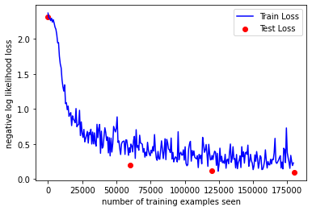

```python
plt_figure()
```

Judging from the training curve() it looks like it could even continue training for a few more epochs!

But before that let's again look at a few examples as it did earlier and compare the model's output.

```python
with torch.no_grad():
    output = network(example_data)
```

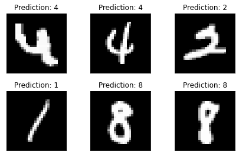

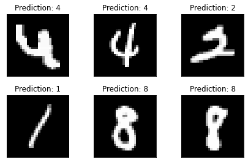

```python
fig = plt.figure()
for i in range(6):
    plt.subplot(2,3,i+1)
    plt.tight_layout()
    plt.imshow(example_data[i][0], cmap='gray', interpolation='none')
    plt.title("Prediction: {}".format(
        output.data.max(1, keepdim=True)[1][i].item()))
    plt.xticks([])
    plt.yticks([])
fig
```

THe model's predictions seem to be on point for those examples!

## Continued Training from Checkpoints

Now let's continue training the network, or rather see how it can continue training from the state_dicts it saved during the first training run. It will initialize a new set of network and optimizers.

```python
continued_network = Net()
continued_optimizer = optim.SGD(network.parameters(), lr=learning_rate,
                                momentum=momentum)
```

Using .load_state_dict() it can now load the internal state of the network and optimizer when it last saved them.

```python
network_state_dict = torch.load('../results/model.pth')
continued_network.load_state_dict(network_state_dict)

optimizer_state_dict = torch.load('../results/optimizer.pth')
continued_optimizer.load_state_dict(optimizer_state_dict)
```

Again running a training loop should immediately pick up the training where it left it. To check on that let's simply use the same lists as before to keep track of the loss values. Due to the way it constructed the test counter for the number of training examples seen it manually has to append to it here.

```python
for i in range(n_epochs+1,n_epochs+1+5):
    test_counter.append(i*len(train_loader.dataset))
    train(i)
    test()
```

```
Train Epoch: 4 [0/60000 (0%)]	Loss: 0.671642
Train Epoch: 4 [640/60000 (1%)]	Loss: 0.186902
Train Epoch: 4 [1280/60000 (2%)]	Loss: 0.193778
Train Epoch: 4 [1920/60000 (3%)]	Loss: 0.311632
Train Epoch: 4 [2560/60000 (4%)]	Loss: 0.243564
Train Epoch: 4 [3200/60000 (5%)]	Loss: 0.243511
Train Epoch: 4 [3840/60000 (6%)]	Loss: 0.267089
Train Epoch: 4 [4480/60000 (7%)]	Loss: 0.313806
Train Epoch: 4 [5120/60000 (9%)]	Loss: 0.223732
Train Epoch: 4 [5760/60000 (10%)]	Loss: 0.286512
Train Epoch: 4 [6400/60000 (11%)]	Loss: 0.292858
Train Epoch: 4 [7040/60000 (12%)]	Loss: 0.276495
Train Epoch: 4 [7680/60000 (13%)]	Loss: 0.188267
Train Epoch: 4 [8320/60000 (14%)]	Loss: 0.322978
Train Epoch: 4 [8960/60000 (15%)]	Loss: 0.111205
Train Epoch: 4 [9600/60000 (16%)]	Loss: 0.262272
Train Epoch: 4 [10240/60000 (17%)]	Loss: 0.141892
Train Epoch: 4 [10880/60000 (18%)]	Loss: 0.384203
Train Epoch: 4 [11520/60000 (19%)]	Loss: 0.248453
Train Epoch: 4 [12160/60000 (20%)]	Loss: 0.340320
Train Epoch: 4 [12800/60000 (21%)]	Loss: 0.229474
Train Epoch: 4 [13440/60000 (22%)]	Loss: 0.090516
Train Epoch: 4 [14080/60000 (23%)]	Loss: 0.263358
Train Epoch: 4 [14720/60000 (25%)]	Loss: 0.291815
Train Epoch: 4 [15360/60000 (26%)]	Loss: 0.154960
Train Epoch: 4 [16000/60000 (27%)]	Loss: 0.158689
Train Epoch: 4 [16640/60000 (28%)]	Loss: 0.333351
Train Epoch: 4 [17280/60000 (29%)]	Loss: 0.247357
Train Epoch: 4 [17920/60000 (30%)]	Loss: 0.144107
Train Epoch: 4 [18560/60000 (31%)]	Loss: 0.140078
Train Epoch: 4 [19200/60000 (32%)]	Loss: 0.503708
Train Epoch: 4 [19840/60000 (33%)]	Loss: 0.068195
Train Epoch: 4 [20480/60000 (34%)]	Loss: 0.143428
Train Epoch: 4 [21120/60000 (35%)]	Loss: 0.218016
Train Epoch: 4 [21760/60000 (36%)]	Loss: 0.305046
Train Epoch: 4 [22400/60000 (37%)]	Loss: 0.191457
Train Epoch: 4 [23040/60000 (38%)]	Loss: 0.176222
Train Epoch: 4 [23680/60000 (39%)]	Loss: 0.418159
Train Epoch: 4 [24320/60000 (41%)]	Loss: 0.367699
Train Epoch: 4 [24960/60000 (42%)]	Loss: 0.279771
```

[output cut: 429 more lines]

```
Train Epoch: 8 [51840/60000 (86%)]	Loss: 0.308314
Train Epoch: 8 [52480/60000 (87%)]	Loss: 0.127005
Train Epoch: 8 [53120/60000 (88%)]	Loss: 0.101337
Train Epoch: 8 [53760/60000 (90%)]	Loss: 0.307046
Train Epoch: 8 [54400/60000 (91%)]	Loss: 0.052637
Train Epoch: 8 [55040/60000 (92%)]	Loss: 0.340722
Train Epoch: 8 [55680/60000 (93%)]	Loss: 0.226644
Train Epoch: 8 [56320/60000 (94%)]	Loss: 0.042814
Train Epoch: 8 [56960/60000 (95%)]	Loss: 0.186899
Train Epoch: 8 [57600/60000 (96%)]	Loss: 0.133043
Train Epoch: 8 [58240/60000 (97%)]	Loss: 0.451223
Train Epoch: 8 [58880/60000 (98%)]	Loss: 0.115776
Train Epoch: 8 [59520/60000 (99%)]	Loss: 0.164514

Test set: Avg. loss: 0.0543, Accuracy: 9817/10000 (98%)
```

Great! It again increases in test set accuracy from epoch to epoch. Let's visualize this to further inspect the training progress.

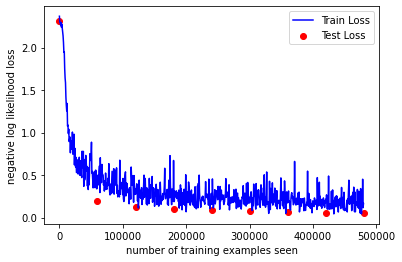

```python
plt_figure()
```